# Problema 4 Checkpoint 1

Luiza Carvalho

24 de julho de 2017

## Introdução

Para essa parte do problema usaremos uma amostra dados de dados da atividade global do github. Os dados brutos contém a contagem de quantas pessoas editaram arquivos com cada extensão de arquivo em cada dia de 2016 e 2017 no github. Não temos dados de todos os repositórios nem de todos os usuários, portanto estamos trabalhando com uma amostra.

### Perguntas

Escolha duas linguagens de programação que lhe interessem e responda o seguinte:

1. Para cada uma delas, há uma diferença significativa na sua popularidade durante a semana e durante o fim de semana? Essa diferença é grande?
2. Existe uma diferença significativa entre as duas linguagens na sua variação de popularidade nos finais de semana?

As linguagens escolhidas foram Java e Python.

## Conhecendo e Manipulando os Dados

O conjunto de dados é uma amostra de dados da atividade global do github, suas variáveis são: a extensão do arquivo, o dia do mês, o mês e o ano em que arquivos com essa extenção foram editados e o número de usuários que editaram os arquivos.

Para responder as perguntas dessa análise precisamos manipular os dados para obter um dataframe com apenas as duas extensões de arquivos escolhidas (py e java) e também será feita uma manipulação para obtermos o dia da semana equivalente a data em que os arquivos com determinada extensão foram editados.

```r
#Importando Dados
dados <- read.csv("github-users-committing-filetypes.csv")

#Selecionando apenas as extensões que serão utilizadas
dados <- dados %>% filter(file_extension == "java" | file_extension == "py")

head(dados)
```

```
##   file_extension month_day the_month the_year users
## 1             py         2         3     2016  5542
## 2             py        24         2     2016  5535
## 3             py        10         3     2016  5531
## 4             py        12         4     2016  5516
## 5             py         3         3     2016  5503
## 6             py         9         3     2016  5502
```

```r
names(dados)
```

```
## [1] "file_extension" "month_day"      "the_month"      "the_year"
## [5] "users"
```

```r
# Obtendo o dia da semana de cada data
dados <- dados %>% mutate(full_date = paste(month_day, the_month, the_year, sep = '-'))

dados <- dados %>% mutate(week_day= weekdays(as.Date(full_date,'%d-%m-%Y')))
```

Para analisar o panorama das edições dos arquivos por mês foi necessária a criação de mais um campo no dataframe, o qual mostra o total de edições feitas para cada linguagem de programação em um mês.

```r
java <- dados %>% filter(file_extension == "java")

java.2017 <- java %>% filter(the_year == 2017)
java.2016 <- java %>% filter(the_year == 2016)

java.2017 <- java.2017 %>% group_by(the_month) %>% mutate(users_month = sum(users))

java.2016 <- java.2016 %>% group_by(the_month) %>% mutate(users_month = sum(users))

java <- rbind(java.2016,java.2017)

py <- dados %>% filter(file_extension == "py")

py.2017 <- py %>% filter(the_year == 2017)
py.2016 <- py %>% filter(the_year == 2016)

py.2017 <- py.2017 %>% group_by(the_month) %>% mutate(users_month = sum(users))

py.2016 <- py.2016 %>% group_by(the_month) %>% mutate(users_month = sum(users))

py <- rbind(py.2016,py.2017)

rm(py.2017)
rm(py.2016)
rm(java.2016)
rm(java.2017)
```

Aqui então temos o sumário da amostra e as novas variáveis adicionadas ao dataframe que serão utilizadas para está análise.

```r
dados <- rbind(py,java)

summary(dados)
```

```
##  file_extension   month_day       the_month         the_year
##  java   :496    Min.   : 1.00   Min.   : 1.000   Min.   :2016
##  py     :496    1st Qu.: 8.00   1st Qu.: 3.000   1st Qu.:2016
##  c      :  0    Median :15.00   Median : 5.000   Median :2016
##  cc     :  0    Mean   :15.49   Mean   : 5.512   Mean   :2016
##  config :  0    3rd Qu.:23.00   3rd Qu.: 8.000   3rd Qu.:2017
##  cpp    :  0    Max.   :31.00   Max.   :12.000   Max.   :2017
##  (Other):  0
##      users       full_date           week_day          users_month
##  Min.   :1116   Length:992         Length:992         Min.   : 19124
##  1st Qu.:2648   Class :character   Class :character   1st Qu.: 93377
##  Median :3622   Mode  :character   Mode  :character   Median :109049
##  Mean   :3588                                         Mean   :108085
##  3rd Qu.:4521                                         3rd Qu.:123114
##  Max.   :5542                                         Max.   :141462
##
```

```r
names(dados)
```

```
## [1] "file_extension" "month_day"      "the_month"      "the_year"
## [5] "users"          "full_date"      "week_day"       "users_month"
```

## Linha do Tempo

A seguir será apresentado a linha do tempo de número de usuários que realizaram edições por mês de cada linguagem de programação que foi escolhida:

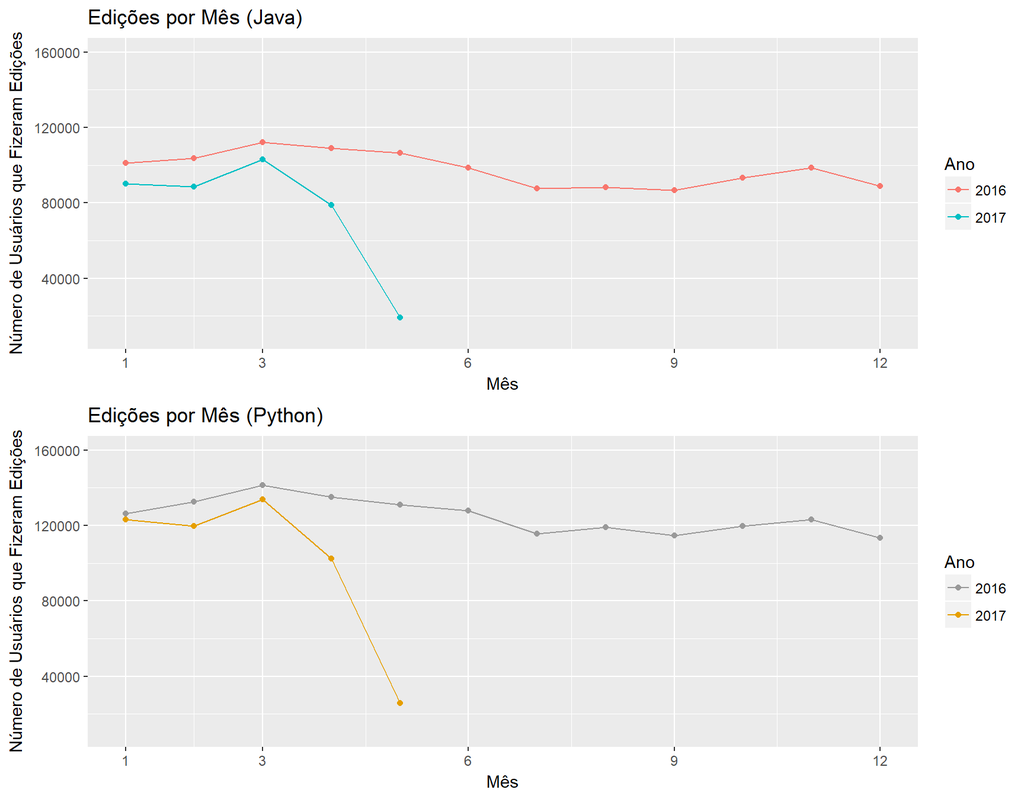

```r
p1 <- java %>% ggplot(aes(x = the_month, y = users_month, colour = as.factor(the_year))) + geom_point()  +geom_line()+  scale_x_continuous(breaks=c(1,3,6,9,12)) + ylim(10000, 160000) + labs(title = "Edições por Mês (Java)", x = "Mês" , y= "Número de Usuários que Fizeram Edições", colour = "Ano")


p2 <- py %>% ggplot(aes(x =the_month, y = users_month, colour = as.factor(the_year))) + geom_point() + geom_line() + ylim(10000, 160000) +  scale_x_continuous(breaks=c(1,3,6,9,12))+ scale_color_manual(values=c("#999999", "#E69F00")) + labs(title = "Edições por Mês (Python)", x = "Mês" , y= "Número de Usuários que Fizeram Edições", colour = "Ano")

grid.arrange(p1, p2)
```

É possível observar que ambas as linguagens se comportam de maneira semelhante, tendo valores relativamente consistentes durante 2016 e uma queda abrupta no quarto e quinto mês de 2017, não há dados sobre as edições feitas após maio de 2017.

Também é possível observar que nessa amostra python em geral possui mais edições do que java, sendo seu total de edições por mês sempre superior ao da outra linguagem.

## Popularidade por Final de Semana vs Dia de Semana (Python)

Abaixo visualizaremos o gráfico que compara a atividade dos usuários que programam em python, separando-a em final de semana e dia da semana:

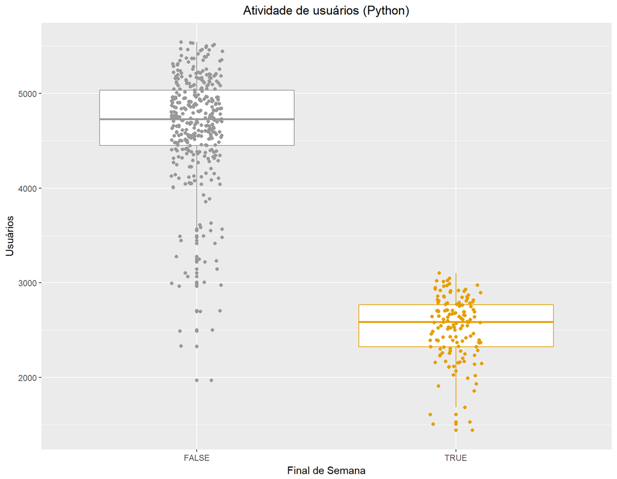

```r
# Separando os dados entre semana e final de semana

py.week <- py %>% filter(week_day != "sábado" & week_day != "domingo")
py.weekend <- py %>% filter(week_day == "sábado" | week_day == "domingo")

java.week <- java %>% filter(week_day != "sábado" & week_day != "domingo")
java.weekend <- java %>% filter(week_day == "sábado" | week_day == "domingo")

py.week$week_day = FALSE
py.weekend$week_day = TRUE

java.week$week_day = FALSE
java.weekend$week_day = TRUE

java <- rbind(java.week,java.weekend)
py <- rbind(py.week,py.weekend)

names(java)[7] <- "weekend"

names(py)[7] <- "weekend"

rm(py.week)
rm(py.weekend)
rm(java.week)
rm(java.weekend)


plot_py <- py %>%
  ggplot(aes(x = weekend, y = users, color = weekend)) +
  geom_boxplot() +  geom_jitter(width = .1) +
  labs(title = "Atividade de usuários (Python)", x = "Final de Semana", y = "Usuários") +
  theme(plot.title = element_text(hjust = 0.5)) + scale_color_manual(values=c("#999999", "#E69F00")) + guides(color=FALSE)

plot_py
```

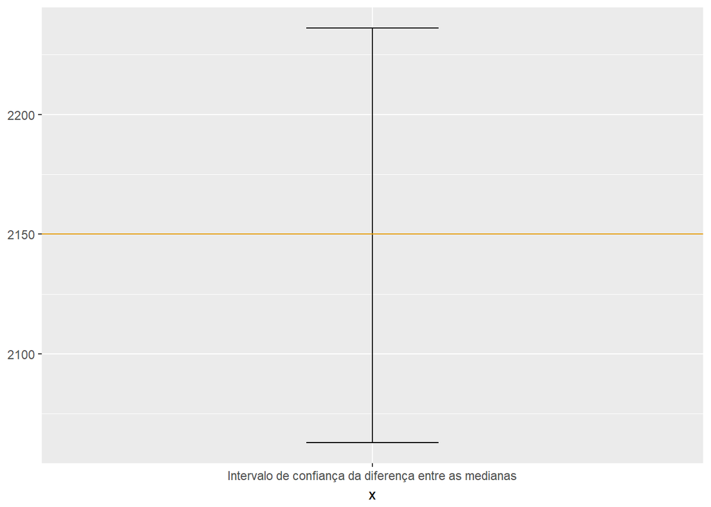

```r
median_py <- bootstrap2(py$users,
                         treatment = py$weekend,
                         median,
                         R = 15000)

median_py_ci <- CI.percentile(median_py, probs = c(.025, .975))

data.frame(median_py_ci) %>%
  ggplot() +
  geom_errorbar(aes(x = "Intervalo de confiança da diferença entre as medianas", ymin = X2.5., ymax = X97.5.), width = .2) +
  geom_hline(yintercept = 2150, colour = "#E69F00")
```

Visualizando o gráfico acima é possível verificar que a conclusão obtida observando a amostra é válida, pois existe uma diferença significativa entre as contribuições nos dias de semana e nos finais de semana, sendo as dos dias de semana no possuindo no mínimo 2062.5 e no máximo 2235.5 atividades de usuário a mais com 95% de confiança.

## Popularidade por Final de Semana vs Dia de Semana (Java)

Abaixo visualizaremos o gráfico que compara a atividade dos usuários que programam em java, separando-a em final de semana e dia da semana:

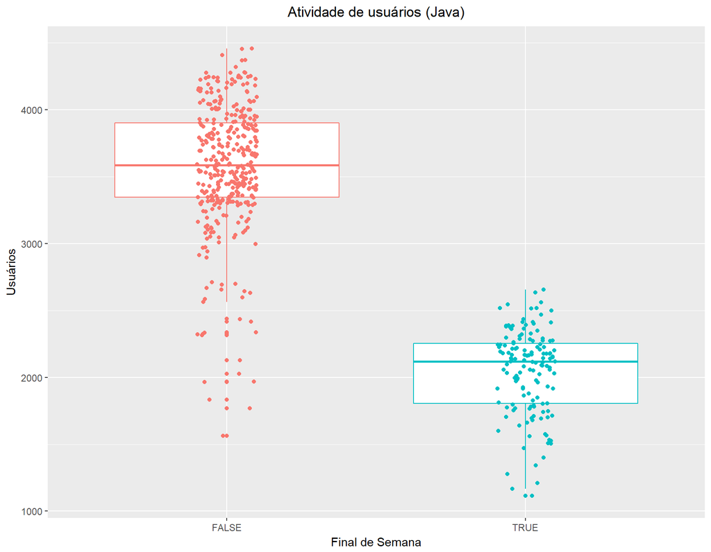

```r
plot_java <- java %>%
  ggplot(aes(x = weekend, y = users, color = weekend)) +
  geom_boxplot() +  geom_jitter(width = .1) +
  labs(title = "Atividade de usuários (Java)", x = "Final de Semana", y = "Usuários") +
  theme(plot.title = element_text(hjust = 0.5))+ guides(color=FALSE)

plot_java
```

Assim como aconteceu com python é visível que existe uma grande diferença entre a contribuição dos usuários nos dias de semana e nos finais de semana, sendo as contribuições nos dias de semana maiores e mais comuns. Também iremos calcular com o bootstrap o intervalo de confiança da subtração das medianas para podermos afirmar que nossa observação é válida.

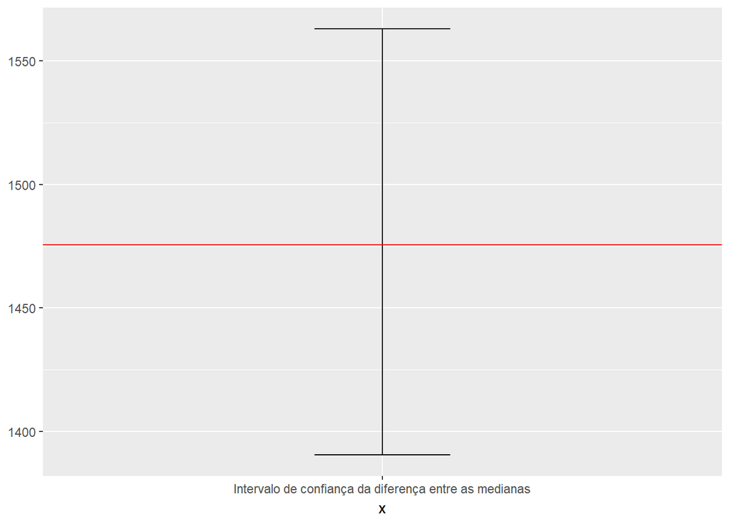

```r
median_ja <- bootstrap2(java$users,
                         treatment = java$weekend,
                         median,
                         R = 15000)

median_ja_ci <- CI.percentile(median_ja, probs = c(.025, .975))

data.frame(median_ja_ci) %>%
  ggplot() +
  geom_errorbar(aes(x = "Intervalo de confiança da diferença entre as medianas", ymin = X2.5., ymax = X97.5.), width = .2) +
  geom_hline(yintercept = 1475.5, colour = "red")
```

Mais uma vez o intervalo de confiança confirma nossa hipótese, mostrando que as atividades nos dias de semana possuem no mínimo 1390.5 e no máximo 1562 atividades de usuário a mais que as do final de semana com 95% de confiança.

## Variação da Popularidade no Final de Semana para ambas linguagens

Para responder a segunda pergunta foi criado um gráfico comparando os boxplots das atividades de usuário nos finais de semana para cada linguagem:

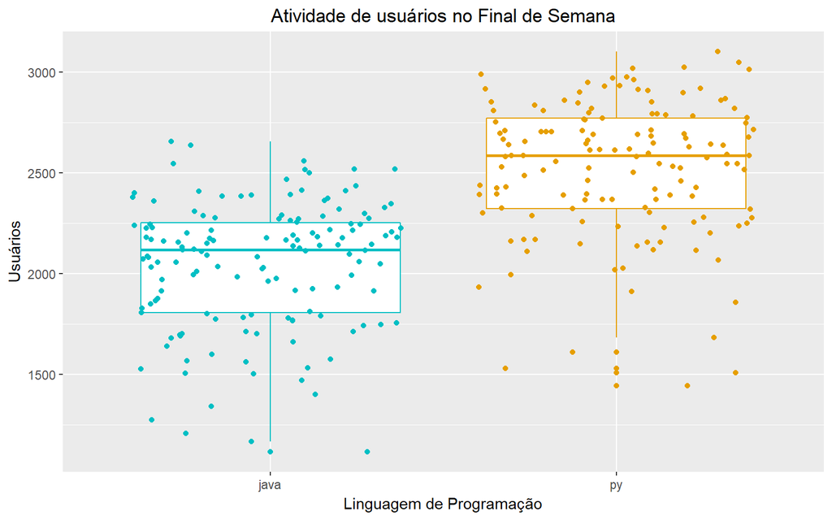

```r
java$language <- "Java"
py$language <- "Python"

dados <- rbind(java,py)
dados <- dados %>% filter(weekend == TRUE)

dados %>% ggplot(aes(y= users, x= file_extension, color= language)) +  geom_boxplot() + geom_jitter() + scale_color_manual(values=c("#00bfc4", "#E69F00")) + guides(color=FALSE) + labs(title = "Atividade de usuários no Final de Semana", x = "Linguagem de Programação", y = "Usuários") + theme(plot.title = element_text(hjust = 0.5))
```

Analisando o gráfico é possível notar que existe uma diferença na casa das centenas entre a popularidade de python e java nos finais de semana, tendo python uma maior popularidade. Para confirmar a veracidade dessa afirmação será calculado o intervalo de confiança entre a diferença da mediana de atividades de python e java no final de semana.

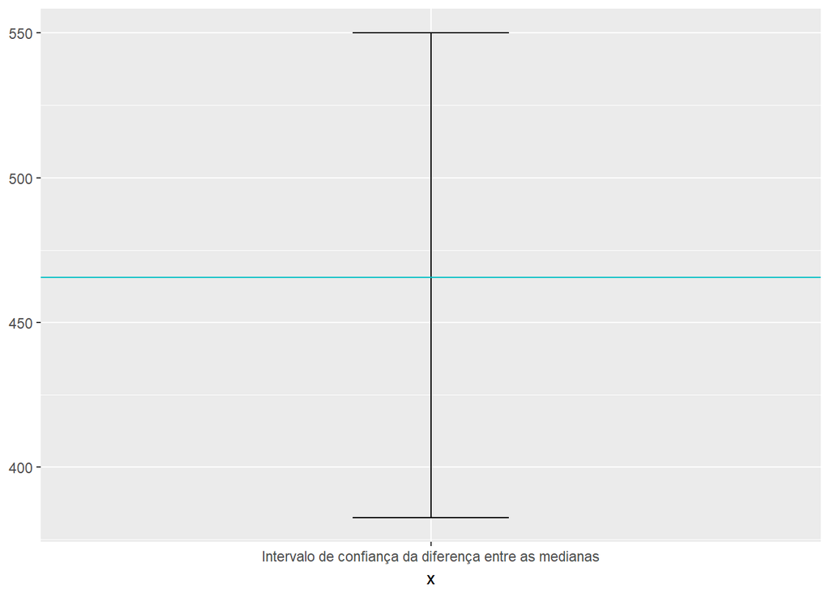

```r
median_japy <- bootstrap2(dados$users,
                         treatment = dados$language,
                         median,
                         R = 15000)

median_japy_ci <- CI.percentile(median_japy, probs = c(.025, .975))

median_japy_ci <- abs(median_japy_ci)

data.frame(median_japy_ci) %>%
  ggplot() +
  geom_errorbar(aes(x = "Intervalo de confiança da diferença entre as medianas", ymin = X2.5., ymax = X97.5.), width = .2) +
  geom_hline(yintercept = 465.5, colour = "#00bfc4")
```

Dessa forma é possível afirmar que nossa conclusão estava correta, pois o intervalo de confiança entre as diferenças das medianas das atividades de usuário de python e java nos finais de semana é de [382,549] com 95% de confiança. Assim temos que Python tem uma popularidade ligeiramente maior nos finais de semana.